# Regression_miHuron

S M Nazarat Hossain

February 25, 2020

```r
# Loading library
library(xts)
library(forecast)
library(forecast)
library(tseries)
library(TSA)
library(knitr)
dataPath <- 'C:/Users/nazar/Desktop/Project_time_series/'
dat <- read.csv(paste0(dataPath,'data.csv'),header = T)
head(dat)
```

```
##   water_levels temperature snow pricipitation sea_level_changes
## 1       176.71        21.0 59.9          7.81          1.791339
## 2       176.73        21.0 59.9          7.81          1.791339
## 3       176.80        50.0  1.4         10.03          1.791339
## 4       176.89        50.0  1.4         10.03          1.791339
## 5       176.99        50.0  1.4         10.03          1.791339
## 6       177.07        71.3    0          5.62          1.791339
##   land_ocean_temperature
## 1                   -0.3
## 2                   -0.3
## 3                   -0.3
## 4                   -0.3
## 5                   -0.3
## 6                   -0.3
```

```r
ts.dat=ts(dat,frequency = 12, start = c(1918,1))
head(ts.dat)
```

```
##          water_levels temperature snow pricipitation sea_level_changes
## Jan 1918       176.71        21.0  166          7.81          1.791339
## Feb 1918       176.73        21.0  166          7.81          1.791339
## Mar 1918       176.80        50.0   14         10.03          1.791339
## Apr 1918       176.89        50.0   14         10.03          1.791339
## May 1918       176.99        50.0   14         10.03          1.791339
## Jun 1918       177.07        71.3    1          5.62          1.791339
##          land_ocean_temperature
## Jan 1918                   -0.3
## Feb 1918                   -0.3
## Mar 1918                   -0.3
## Apr 1918                   -0.3
## May 1918                   -0.3
## Jun 1918                   -0.3
```

Split data into train and test dataset

```r
tsreg.train<-window(ts.dat,start=c(1918,1),end=c(2015,12))
tsreg.test<-window(ts.dat,start=c(2016,1),end=c(2019,12))
tail(tsreg.test)
```

```
##          water_levels temperature snow pricipitation sea_level_changes
## Jul 2019       177.37        72.6    1         10.62          8.980315
## Aug 2019       177.32        72.6    1         10.62          8.980315
## Sep 2019       177.28        51.7  183         16.24          8.980315
## Oct 2019       177.29        51.7  183         16.24          8.980315
## Nov 2019       177.26        51.7  183         16.24          8.980315
## Dec 2019       177.25        26.7  104          8.09          8.980315
##          land_ocean_temperature
## Jul 2019                   0.98
## Aug 2019                   0.98
## Sep 2019                   0.98
## Oct 2019                   0.98
## Nov 2019                   0.98
## Dec 2019                   0.98
```

# Group 1

# All variables

```r
tsreg <- tslm(water_levels~ temperature + snow + pricipitation + sea_level_changes + land_ocean_temperature, data = tsreg.train)
summary(tsreg)
```

```
##
## Call:
## tslm(formula = water_levels ~ temperature + snow + pricipitation +
##     sea_level_changes + land_ocean_temperature, data = tsreg.train)
##
## Residuals:
##      Min       1Q   Median       3Q      Max
## -1.05939 -0.30233 -0.00455  0.29464  0.98354
##
## Coefficients:
##                          Estimate Std. Error  t value Pr(>|t|)
## (Intercept)             1.757e+02  7.219e-02 2433.739  < 2e-16 ***
## temperature             6.146e-03  9.379e-04    6.553 8.44e-11 ***
## snow                    5.404e-04  2.108e-04    2.564   0.0105 *
## pricipitation           4.660e-03  3.459e-03    1.347   0.1782
## sea_level_changes       8.836e-02  1.225e-02    7.211 9.93e-13 ***
## land_ocean_temperature -7.153e-01  8.723e-02   -8.201 6.23e-16 ***
## ---
## Signif. codes:  0 '***' 0.001 '**' 0.01 '*' 0.05 '.' 0.1 ' ' 1
##
## Residual standard error: 0.3764 on 1170 degrees of freedom
## Multiple R-squared:  0.1093, Adjusted R-squared:  0.1055
## F-statistic: 28.72 on 5 and 1170 DF,  p-value: < 2.2e-16
```

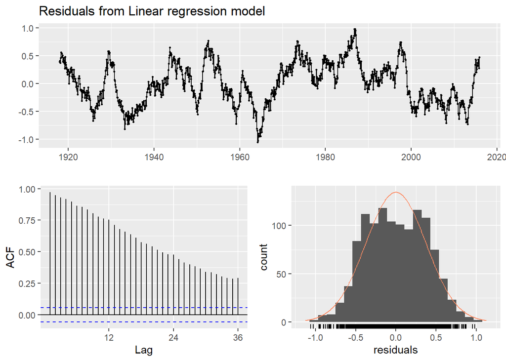

```
##
##  Breusch-Godfrey test for serial correlation of order up to 24
##
## data:  Residuals from Linear regression model
## LM test = 1143.8, df = 24, p-value < 2.2e-16
```

```r
checkresiduals(tsreg)
```

```r
Box.test(tsreg$residuals,lag=12,type="Ljung-Box")
```

```
##
##  Box-Ljung test
##
## data:  tsreg$residuals
## X-squared = 10576, df = 12, p-value < 2.2e-16
```

From summary we can see that Adjusted R-sqr is very low. In addition, with checkresidual acf we can see that **there are corelation information still left in the residual.** Residual is a normal distribution. This model does not capture all the information.

```r
fcast.tsreg <- forecast(tsreg, newdata = data.frame(tsreg.test))
fcast.tsreg$mean
```

```
##           Jan      Feb      Mar      Apr      May      Jun      Jul      Aug
## 2016 176.0086 176.0086 176.1821 176.1821 176.1821 176.2666 176.2666 176.2666
## 2017 176.0782 176.0782 176.2972 176.2972 176.2972 176.3505 176.3505 176.3505
## 2018 176.1392 176.1392 176.3175 176.3175 176.3175 176.3958 176.3958 176.3958
## 2019 176.0424 176.0424 176.2497 176.2497 176.2497 176.2807 176.2807 176.2807
##           Sep      Oct      Nov      Dec
## 2016 176.1452 176.1452 176.1452 176.0086
## 2017 176.1988 176.1988 176.1988 176.0782
## 2018 176.2674 176.2674 176.2674 176.1392
## 2019 176.2767 176.2767 176.2767 176.0424
```

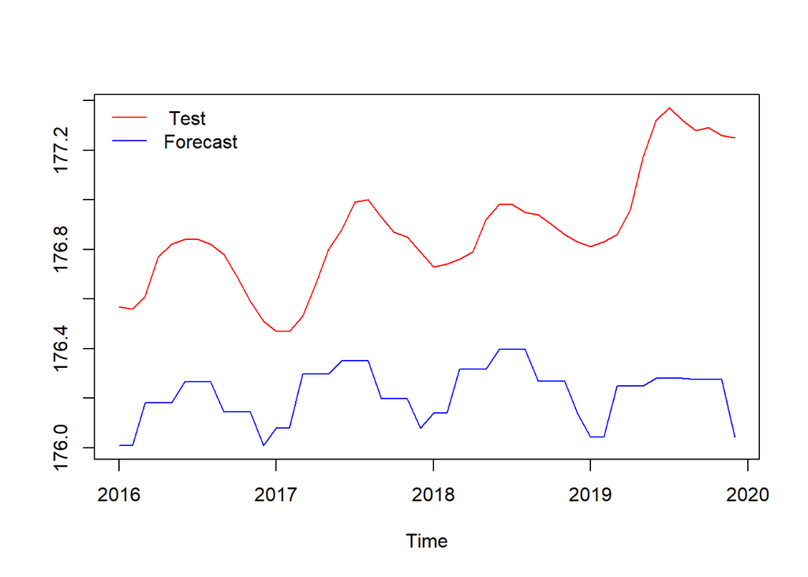

```r
ts.plot(data.frame(tsreg.test)$water_levels,fcast.tsreg$mean, col = c("red", "blue"))
legend("topleft", bty="n", lty=c(1,1), col=c("red","blue"),
       legend=c(" Test ", "Forecast"))
```

# sarima regression model with d=1, D=1, and lambda = 0

```r
tsreg.sarima1 <- auto.arima(tsreg.train[,"water_levels"], xreg = tsreg.train[,2:6 ], d=1, D=1,lambda = 0)
summary(tsreg.sarima1)
```

```
## Series: tsreg.train[, "water_levels"]
## Regression with ARIMA(3,1,0)(2,1,0)[12] errors
## Box Cox transformation: lambda= 0
##
## Coefficients:
```

```
##          ar1     ar2     ar3    sar1     sar2  temperature  snow  pricipitation
##       0.4859  0.0040  0.0794  -0.661  -0.3610            0     0              0
## s.e.  0.0221  0.0311  0.0240   0.026   0.0243          NaN   NaN            NaN
##       sea_level_changes  land_ocean_temperature
##                   2e-04                   3e-04
## s.e.                NaN                   0e+00
##
## sigma^2 estimated as 3.543e-07:  log likelihood=8098.57
## AIC=-16175.14   AICc=-16174.91   BIC=-16119.49
##
## Training set error measures:
##                        ME      RMSE        MAE          MPE      MAPE      MASE
## Training set -0.001813524 0.1049119 0.03545334 -0.001022158 0.0200903 0.1784472
##                  ACF1
## Training set 0.144015
```

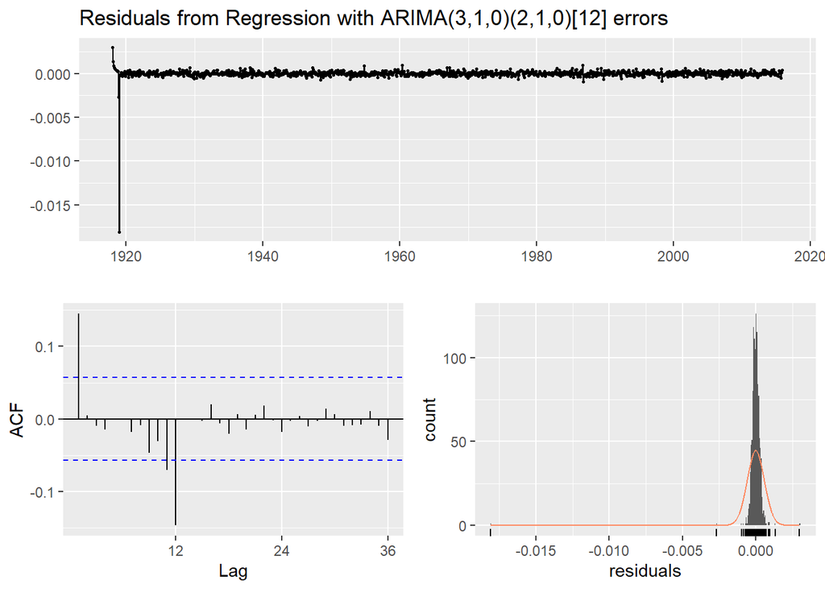

```
##
##  Ljung-Box test
##
## data:  Residuals from Regression with ARIMA(3,1,0)(2,1,0)[12] errors
## Q* = 62.852, df = 14, p-value = 3.686e-08
##
## Model df: 10.   Total lags used: 24
```

```r
checkresiduals(tsreg.sarima1)
```

ACF of residuals shows that there is auto-corelation existing in residual. Box test also shows the p-value of box test is less than 0.05 we can reject null hypothisis that the data is independently distributed.

# sarima regression model with d=1, D=1, and lambda = 0.5

```r
tsreg.sarima2 <- auto.arima(tsreg.train[,"water_levels"], xreg = tsreg.train[,c(2:6) ], d=1, D=1,lambda = 0.5)
summary(tsreg.sarima2)
```

```
## Series: tsreg.train[, "water_levels"]
## Regression with ARIMA(3,1,0)(2,1,0)[12] errors
## Box Cox transformation: lambda= 0.5
##
## Coefficients:
##          ar1     ar2     ar3     sar1     sar2  temperature  snow
##       0.4865  0.0037  0.0793  -0.6622  -0.3618        0e+00     0
## s.e.  0.0305  0.0336  0.0302   0.0279   0.0279        1e-04     0
##       pricipitation  sea_level_changes  land_ocean_temperature
##                   0             0.0024                  0.0039
## s.e.              0             0.0001                  0.0027
##
## sigma^2 estimated as 1.608e-05:  log likelihood=5090.65
## AIC=-10159.29   AICc=-10159.06   BIC=-10103.65
##
## Training set error measures:
##                         ME       RMSE        MAE           MPE       MAPE
## Training set -0.0005089549 0.05279513 0.03261751 -0.0002838631 0.01848601
##                   MASE       ACF1
## Training set 0.1641736 0.08498471
```

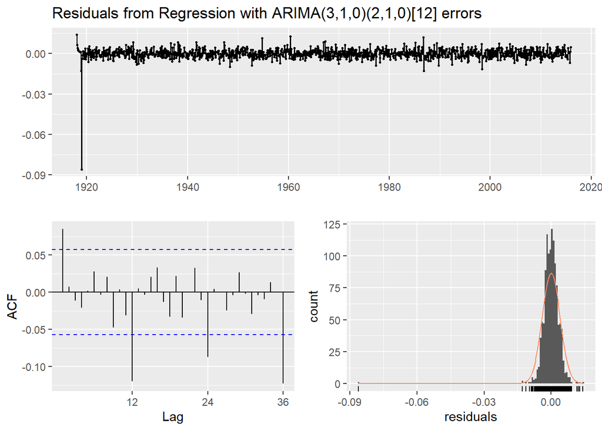

```
##
##  Ljung-Box test
##
## data:  Residuals from Regression with ARIMA(3,1,0)(2,1,0)[12] errors
## Q* = 47.445, df = 14, p-value = 1.624e-05
##
## Model df: 10.   Total lags used: 24
```

```r
checkresiduals(tsreg.sarima2)
```

# sarima regression model with d=1, D=1, and lambda = 1

```r
tsreg.sarima3 <- auto.arima(tsreg.train[,"water_levels"], xreg = tsreg.train[,c(2:6) ], d=1, D=1,lambda = 1)
summary(tsreg.sarima3)
```

```
## Series: tsreg.train[, "water_levels"]
## Regression with ARIMA(3,1,0)(2,1,0)[12] errors
## Box Cox transformation: lambda= 1
##
## Coefficients:
##          ar1     ar2     ar3     sar1     sar2  temperature  snow
##       0.4866  0.0035  0.0791  -0.6623  -0.3619        6e-04     0
## s.e.  0.0295  0.0331  0.0298   0.0277   0.0276        4e-04     0
##       pricipitation  sea_level_changes  land_ocean_temperature
##              -2e-04             0.0320                  0.0516
## s.e.          3e-04             0.0026                  0.0271
##
## sigma^2 estimated as 0.001983:  log likelihood=2082.45
## AIC=-4142.89   AICc=-4142.66   BIC=-4087.25
##
## Training set error measures:
##                         ME       RMSE        MAE           MPE       MAPE
## Training set -0.0001738003 0.04409212 0.03189385 -9.418377e-05 0.01807662
##                   MASE       ACF1
## Training set 0.1605312 0.04246463
```

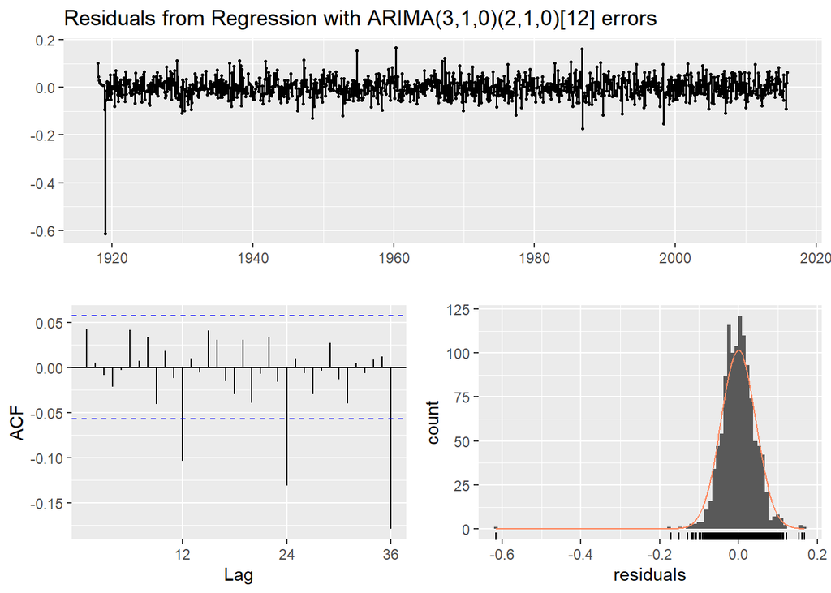

```
##
##  Ljung-Box test
##
## data:  Residuals from Regression with ARIMA(3,1,0)(2,1,0)[12] errors
## Q* = 51.347, df = 14, p-value = 3.625e-06
##
## Model df: 10.   Total lags used: 24
```

```r
checkresiduals(tsreg.sarima3)
```

# sarima regression model with d=1, D=1, and lambda = 2

```r
tsreg.sarima4 <- auto.arima(tsreg.train[,"water_levels"], xreg = tsreg.train[,c(2:6) ], d=1, D=1,lambda = 2)
summary(tsreg.sarima4)
```

```
## Series: tsreg.train[, "water_levels"]
## Regression with ARIMA(3,1,0)(2,1,0)[12] errors
## Box Cox transformation: lambda= 2
##
## Coefficients:
##          ar1     ar2     ar3     sar1     sar2  temperature     snow
##       0.4868  0.0034  0.0789  -0.6622  -0.3620       0.1064  -0.0022
## s.e.  0.0295  0.0332  0.0299   0.0277   0.0277       0.0629   0.0036
##       pricipitation  sea_level_changes  land_ocean_temperature
##             -0.0290             5.6546                   9.119
## s.e.         0.0584             2.6961                   4.814
##
## sigma^2 estimated as 53.66:  log likelihood=-3934
## AIC=7889.99   AICc=7890.22   BIC=7945.64
##
## Training set error measures:
##                        ME       RMSE        MAE        MPE       MAPE      MASE
## Training set 2.715712e-05 0.04109963 0.03147869 1.9555e-05 0.01784177 0.1584416
##                    ACF1
## Training set 0.01705132
```

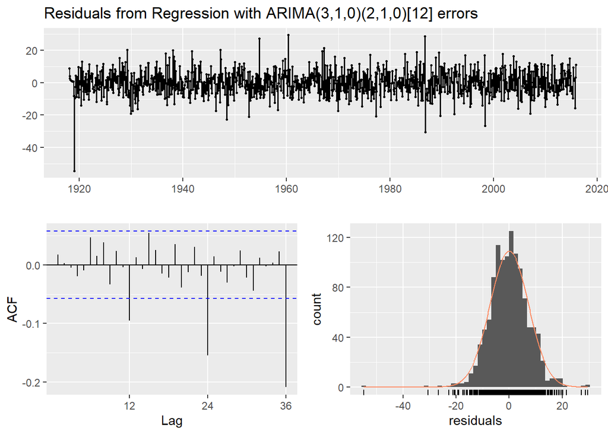

```
##
##  Ljung-Box test
##
## data:  Residuals from Regression with ARIMA(3,1,0)(2,1,0)[12] errors
## Q* = 57.195, df = 14, p-value = 3.619e-07
##
## Model df: 10.   Total lags used: 24
```

```r
checkresiduals(tsreg.sarima4)
```

```r
AIC<-cbind("1-1-0"=tsreg.sarima1$aic,"1-1-0.5"=tsreg.sarima2$aic,"1-1-1"=tsreg.sarima3$aic,"1-1-2"=tsreg.sarima4$aic)
AIC
```

```
##          1-1-0   1-1-0.5     1-1-1    1-1-2
## [1,] -16175.14 -10159.29 -4142.893 7889.993
```

The model has some significant autocorrelation in the residuals, which means the prediction intervals may not provide accurate coverage.

Also, the histogram of the residuals shows one negative outlier, which will also affect the coverage of the prediction intervals.

```r
Residuals<-cbind("1-1-0"=tsreg.sarima1$residuals,"1-1-0.5"=tsreg.sarima2$residuals,"1-1-1"=tsreg.sarima3$residuals,"1-1-2"=tsreg.sarima4$residuals)
#Residuals
```

# Group 2

# Variables snow+pricipitation+sea_level_chnages

# sarima regression model with d=1, D=1, and lambda = 0

```r
tsreg.sarima5 <- auto.arima(tsreg.train[,"water_levels"], xreg = tsreg.train[,3:5 ], d=1, D=1,lambda = 0)
summary(tsreg.sarima5)
```

```
## Series: tsreg.train[, "water_levels"]
## Regression with ARIMA(1,1,2)(2,1,0)[12] errors
## Box Cox transformation: lambda= 0
##
## Coefficients:
```

```
##          ar1      ma1      ma2     sar1     sar2  snow  pricipitation
##       0.7532  -0.2668  -0.1326  -0.6623  -0.3622     0              0
## s.e.  0.0612   0.0696   0.0371   0.0268   0.0251   NaN            NaN
##       sea_level_changes
##                   2e-04
## s.e.                NaN
##
## sigma^2 estimated as 3.54e-07:  log likelihood=8095.3
## AIC=-16172.61   AICc=-16172.45   BIC=-16127.08
##
## Training set error measures:
##                        ME      RMSE        MAE          MPE       MAPE
## Training set -0.001818962 0.1049552 0.03561366 -0.001025211 0.02018115
##                   MASE      ACF1
## Training set 0.1792541 0.1438273
```

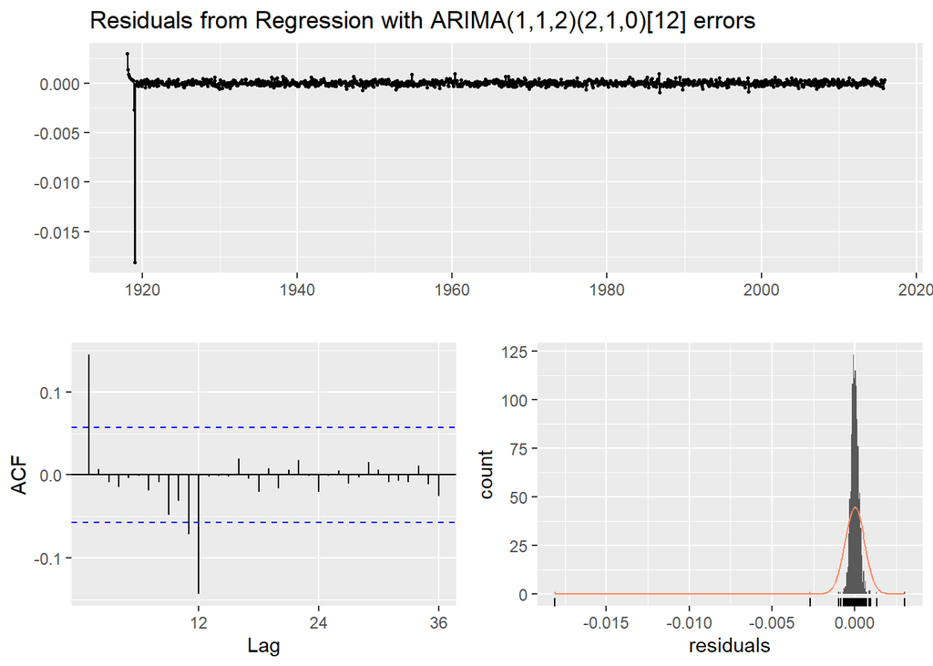

```
##
##  Ljung-Box test
##
## data:  Residuals from Regression with ARIMA(1,1,2)(2,1,0)[12] errors
## Q* = 62.465, df = 16, p-value = 2.001e-07
##
## Model df: 8.   Total lags used: 24
```

```r
checkresiduals(tsreg.sarima5)
```

ACF of residuals shows that there is auto-corelation existing in residual. Box test also shows the p-value of box test is less than 0.05 we can reject null hypothisis that the data is independently distributed.

# sarima regression model with d=1, D=1, and lambda = 0.5

```r
tsreg.sarima6 <- auto.arima(tsreg.train[,"water_levels"], xreg = tsreg.train[,c(3:5) ], d=1, D=1,lambda = 0.5)
summary(tsreg.sarima6)
```

```
## Series: tsreg.train[, "water_levels"]
## Regression with ARIMA(1,1,2)(2,1,0)[12] errors
## Box Cox transformation: lambda= 0.5
##
## Coefficients:
##          ar1      ma1      ma2     sar1     sar2  snow  pricipitation
##       0.7507  -0.2636  -0.1313  -0.6633  -0.3628     0              0
## s.e.  0.0622   0.0710   0.0485   0.0277   0.0276     0              0
##       sea_level_changes
##                  0.0026
## s.e.             0.0000
##
## sigma^2 estimated as 1.61e-05:  log likelihood=5087.34
## AIC=-10156.68   AICc=-10156.52   BIC=-10111.15
##
## Training set error measures:
##                         ME       RMSE      MAE           MPE       MAPE
## Training set -0.0005188592 0.05288173 0.032764 -0.0002894454 0.01856902
##                   MASE       ACF1
## Training set 0.1649109 0.08433926
```

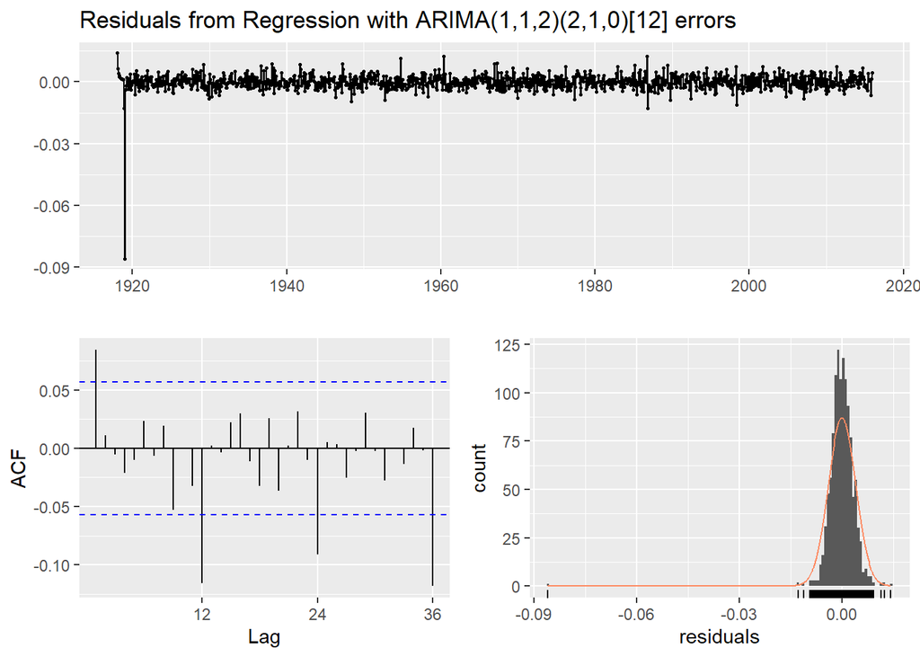

```
##
##  Ljung-Box test
##
## data:  Residuals from Regression with ARIMA(1,1,2)(2,1,0)[12] errors
## Q* = 47.599, df = 16, p-value = 5.49e-05
##
## Model df: 8.   Total lags used: 24
```

```r
checkresiduals(tsreg.sarima6)
```

# sarima regression model with d=1, D=1, and lambda = 1

```r
tsreg.sarima7 <- auto.arima(tsreg.train[,"water_levels"], xreg = tsreg.train[,c(3:5) ], d=1, D=1,lambda = 1)
summary(tsreg.sarima7)
```

```
## Series: tsreg.train[, "water_levels"]
## Regression with ARIMA(1,1,2)(2,1,0)[12] errors
## Box Cox transformation: lambda= 1
##
## Coefficients:
```

```
##          ar1      ma1      ma2     sar1     sar2  snow  pricipitation
##       0.7499  -0.2626  -0.1310  -0.6634  -0.3629     0         -1e-04
## s.e.  0.0623   0.0711   0.0486   0.0277   0.0276     0          3e-04
##       sea_level_changes
##                  0.0346
## s.e.                NaN
##
## sigma^2 estimated as 0.001989:  log likelihood=2079.13
## AIC=-4140.26   AICc=-4140.1   BIC=-4094.73
##
## Training set error measures:
##                         ME       RMSE        MAE           MPE       MAPE
## Training set -0.0001847678 0.04419607 0.03203825 -0.0001003681 0.01815845
##                  MASE       ACF1
## Training set 0.161258 0.04167266
```

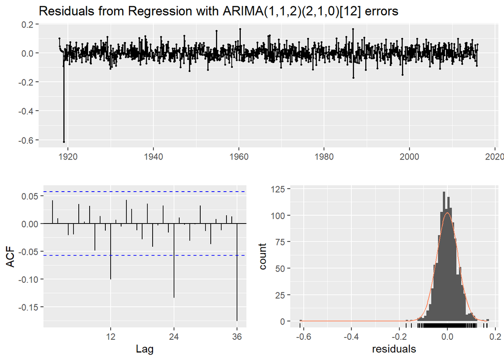

```
##
##  Ljung-Box test
##
## data:  Residuals from Regression with ARIMA(1,1,2)(2,1,0)[12] errors
## Q* = 51.857, df = 16, p-value = 1.155e-05
##
## Model df: 8.   Total lags used: 24
```

```r
checkresiduals(tsreg.sarima7)
```

# sarima regression model with d=1, D=1, and lambda = 2

```r
tsreg.sarima8 <- auto.arima(tsreg.train[,"water_levels"], xreg = tsreg.train[,c(3:5) ], d=1, D=1,lambda = 2)
summary(tsreg.sarima8)
```

```
## Series: tsreg.train[, "water_levels"]
## Regression with ARIMA(1,1,2)(2,1,0)[12] errors
## Box Cox transformation: lambda= 2
##
## Coefficients:
##          ar1      ma1      ma2     sar1     sar2     snow  pricipitation
##       0.7489  -0.2614  -0.1307  -0.6633  -0.3630  -0.0036        -0.0241
## s.e.  0.0626   0.0714   0.0487   0.0277   0.0277   0.0036         0.0583
##       sea_level_changes
##                  6.1003
## s.e.             2.6665
##
## sigma^2 estimated as 53.86:  log likelihood=-3937.32
## AIC=7892.65   AICc=7892.8   BIC=7938.18
##
## Training set error measures:
##                        ME       RMSE       MAE         MPE       MAPE      MASE
## Training set 1.573511e-05 0.04121158 0.0316218 1.31133e-05 0.01792287 0.1591619
##                    ACF1
## Training set 0.01628005
```

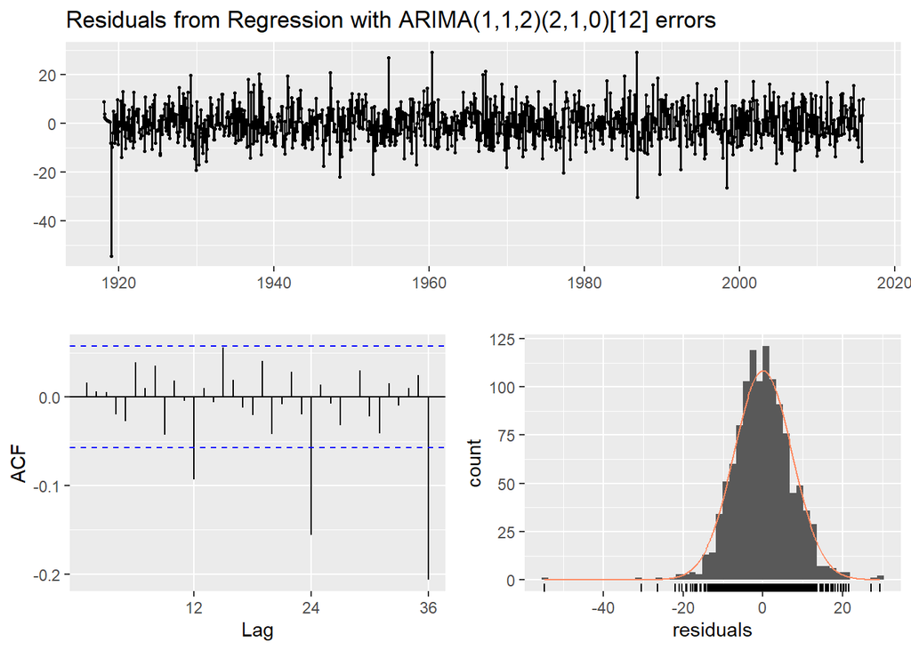

```
##
##  Ljung-Box test
##
## data:  Residuals from Regression with ARIMA(1,1,2)(2,1,0)[12] errors
## Q* = 57.844, df = 16, p-value = 1.203e-06
##
## Model df: 8.   Total lags used: 24
```

```r
checkresiduals(tsreg.sarima8)
```

# Group 3

# Var Model

```r
library(vars)
m.var<-VAR(tsreg.train[,c(1:6)],p=10,type = "both",season = 12)
#summary(m.var)
serial.test(m.var, lags.pt = 10, type = "PT.asymptotic")
```

```
##
##  Portmanteau Test (asymptotic)
##
## data:  Residuals of VAR object m.var
## Chi-squared = 61.83, df = 0, p-value < 2.2e-16
```

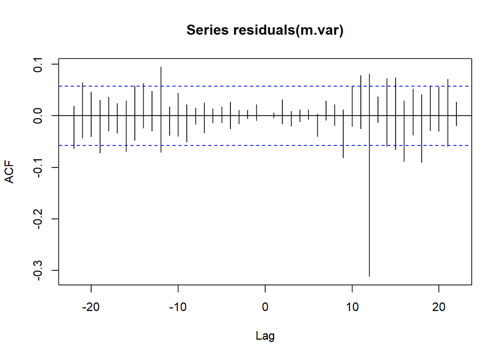

```r
acf(residuals(m.var))
```

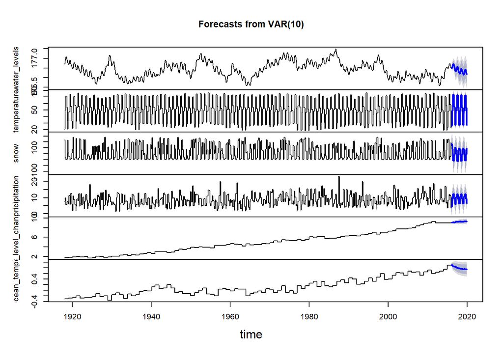

```r
fcast.m.var<-forecast(m.var,h=48)
plot(fcast.m.var)
```

# Group 4

# using log

```r
df.ts.dat<-data.frame("time"=index(tsreg.train[,"water_levels"]),"water_levels"=tsreg.train[,"water_levels"],"temperature"=tsreg.train[,"temperature"],"snow"=tsreg.train[,"snow"],"pricipitation"=tsreg.train[,"pricipitation"],"sea_level_changes"=tsreg.train[,"sea_level_changes"])
df.ts.dat<-data.frame(df.ts.dat)
ts.dat.log<-data.frame("water_levels.log"=log(df.ts.dat$water_levels),"temperature.log"=log(df.ts.dat$temperature),"snow.log"=log(df.ts.dat$snow),"pricipitation.log"=log(df.ts.dat$pricipitation), "sea_level_changes.log"=log(df.ts.dat$sea_level_changes))
log.ts.lm1<-tslm(water_levels.log~.,data=ts.dat.log)
summary(log.ts.lm1)
```

```
##
## Call:
## tslm(formula = water_levels.log ~ ., data = ts.dat.log)
##
## Residuals:
##        Min         1Q     Median         3Q        Max
## -0.0049074 -0.0017548 -0.0000873  0.0015831  0.0057485
##
## Coefficients:
##                         Estimate Std. Error  t value Pr(>|t|)
## (Intercept)            5.170e+00  2.684e-03 1926.128  < 2e-16 ***
## temperature.log       -8.597e-04  7.942e-04   -1.082 0.279261
## snow.log               1.551e-04  5.907e-05    2.626 0.008745 **
## pricipitation.log      3.976e-04  1.664e-04    2.389 0.017040 *
## sea_level_changes.log  4.980e-03  7.028e-04    7.087 2.38e-12 ***
## trend                 -6.940e-06  1.015e-06   -6.837 1.31e-11 ***
## season2               -8.327e-05  3.035e-04   -0.274 0.783828
## season3                3.787e-04  5.686e-04    0.666 0.505459
## season4                8.607e-04  5.686e-04    1.514 0.130390
## season5                1.422e-03  5.687e-04    2.501 0.012519 *
## season6                2.727e-03  8.612e-04    3.167 0.001582 **
## season7                2.904e-03  8.612e-04    3.373 0.000769 ***
## season8                2.799e-03  8.612e-04    3.251 0.001185 **
## season9                1.943e-03  6.294e-04    3.087 0.002073 **
## season10               1.573e-03  6.294e-04    2.499 0.012585 *
## season11               1.251e-03  6.294e-04    1.988 0.047038 *
## season12               2.858e-04  3.037e-04    0.941 0.346809
## ---
## Signif. codes:  0 '***' 0.001 '**' 0.01 '*' 0.05 '.' 0.1 ' ' 1
##
## Residual standard error: 0.002124 on 1159 degrees of freedom
## Multiple R-squared:  0.125,  Adjusted R-squared:  0.1129
## F-statistic: 10.35 on 16 and 1159 DF,  p-value: < 2.2e-16
```

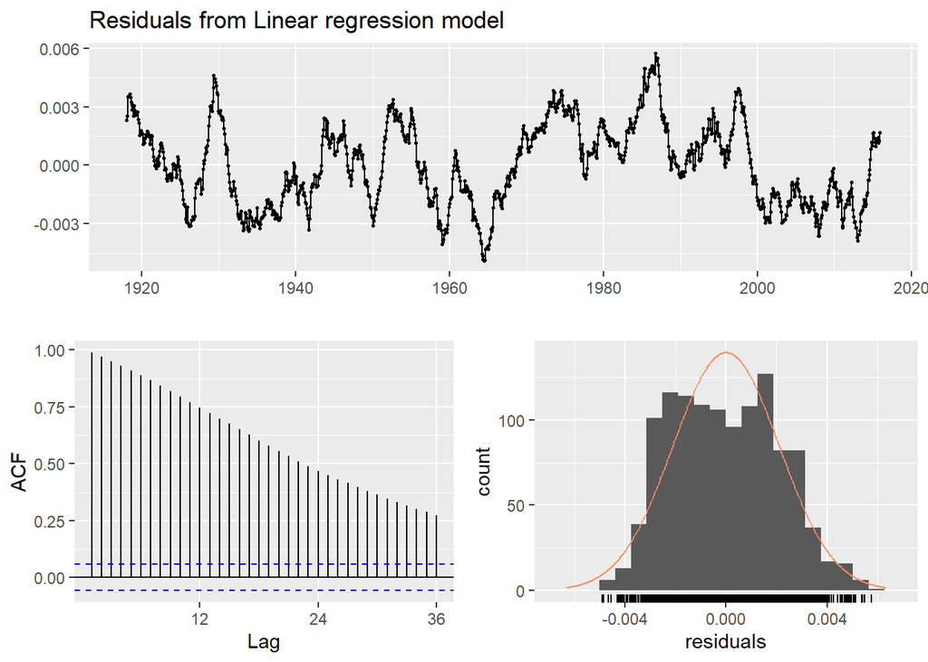

```
##
##  Breusch-Godfrey test for serial correlation of order up to 24
##
## data:  Residuals from Linear regression model
## LM test = 1151.4, df = 24, p-value < 2.2e-16
```

```r
checkresiduals(log.ts.lm1)
```

```r
log.ts.lm2<-tslm(water_levels.log~snow.log++pricipitation.log+sea_level_changes.log,data=ts.dat.log, d=1, D=1, lambda = 1)
summary(log.ts.lm2)
```

[output not shown]

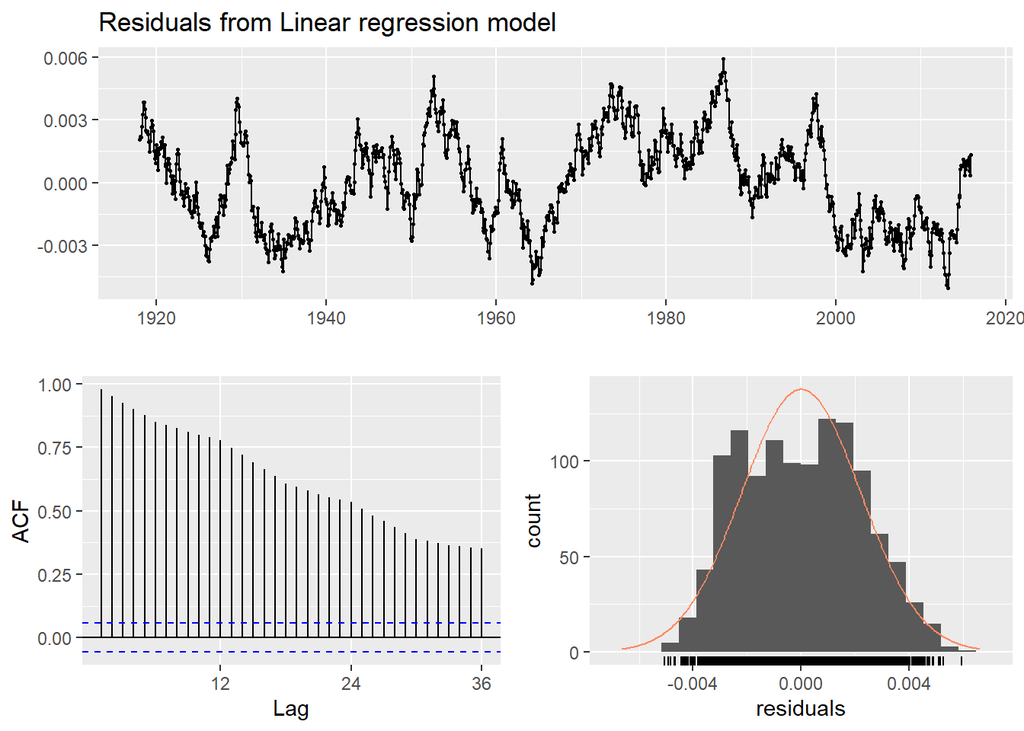

```
##
##  Breusch-Godfrey test for serial correlation of order up to 24
##
## data:  Residuals from Linear regression model
## LM test = 1142.8, df = 24, p-value < 2.2e-16
```

```r
checkresiduals(log.ts.lm2)
```